# R Notebook

*8. In this exercise, we will generate simulated data, and will then use this data to perform best subset selection.*

1. Use the rnorm() function to generate a predictor X of length n = 100, as well as a noise vector ϵ of length n = 100.

```r
set.seed(1)
X = rnorm(100)
eps = rnorm(100)
```

2. Generate a response vector Y of length n = 100 according to the model Y = β0 + β1X + β2X2 + β3X3 + ϵ, where β0, β1, β2, and β3 are constants of your choice.

By selecting β0 = 3, β1 = 2, β2 = -3, and β3 = 0.3

```r
beta0 = 3
beta1 = 2
beta2 = -3
beta3 = 0.3
Y = beta0 + beta1 * X + beta2 * X^2 + beta3 * X^3 + eps
```

3. Use the reg subsets() function to perform best subset selection in order to choose the best model containing the predictors X, X2,…,X10. What is the best model obtained according to Cp, BIC, and adjusted R2? Show some plots to provide evidence for your answer, and report the coefficients of the best model obtained. Note you will need to use the data.frame() function to create a single data set containing both X and Y .

```r
# Use regsubsets to select best model having polynomial of X of degree 10

install.packages("leaps")
library(leaps)
data.full = data.frame(y = Y, x = X)
mod.full = regsubsets(y ~ poly(x, 10, raw = T), data = data.full, nvmax = 10)
mod.summary = summary(mod.full)

# Find the model size for best cp, BIC and adjr2
which.min(mod.summary$cp)
```

```
[1] 3
```

```r
which.min(mod.summary$bic)
```

```
[1] 3
```

```r
which.max(mod.summary$adjr2)
```

```
[1] 3
```

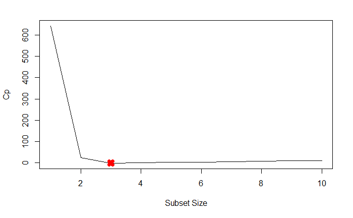

```r
# Plot cp, BIC and adjr2
plot(mod.summary$cp, xlab = "Subset Size", ylab = "Cp", pch = 20, type = "l")
points(3, mod.summary$cp[3], pch = 4, col = "red", lwd = 7)
```

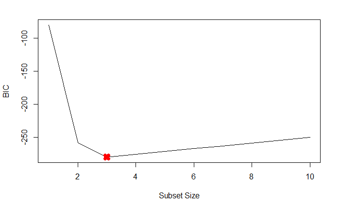

```r
plot(mod.summary$bic, xlab = "Subset Size", ylab = "BIC", pch = 20, type = "l")
points(3, mod.summary$bic[3], pch = 4, col = "red", lwd = 7)
```

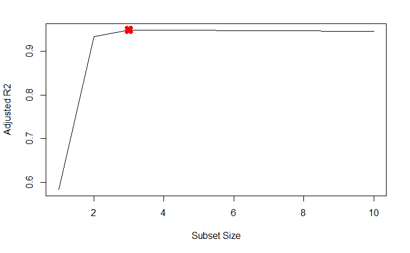

```r
plot(mod.summary$adjr2, xlab = "Subset Size", ylab = "Adjusted R2", pch = 20,
    type = "l")
points(3, mod.summary$adjr2[3], pch = 4, col = "red", lwd = 7)
```

We find that with Cp, BIC and Adjusted R2 criteria, 3, 3, and 3 variable models are respectively picked.

```r
coefficients(mod.full, id = 3)
```

```
          (Intercept) poly(x, 10, raw = T)1 poly(x, 10, raw = T)2
           3.07627412            2.35623596           -3.16514887
poly(x, 10, raw = T)7
           0.01046843
```

All statistics pick X7 over X3. The remaining coefficients are quite close to β s.

4. Repeat (c), using forward stepwise selection and also using backwards stepwise selection. How does your answer compare to the results in (c)?

```r
mod.fwd = regsubsets(y ~ poly(x, 10, raw = T), data = data.full, nvmax = 10,
    method = "forward")
mod.bwd = regsubsets(y ~ poly(x, 10, raw = T), data = data.full, nvmax = 10,
    method = "backward")
fwd.summary = summary(mod.fwd)
bwd.summary = summary(mod.bwd)
which.min(fwd.summary$cp)
```

```
[1] 3
```

```r
which.min(bwd.summary$cp)
```

```
[1] 3
```

```r
which.min(fwd.summary$bic)
```

```
[1] 3
```

```r
which.min(bwd.summary$bic)
```

```
[1] 3
```

```r
which.max(fwd.summary$adjr2)
```

```
[1] 3
```

```r
which.max(bwd.summary$adjr2)
```

```
[1] 3
```

```r
# Plot the statistics
par(mfrow = c(3, 2))
plot(fwd.summary$cp, xlab = "Subset Size", ylab = "Forward Cp", pch = 20, type = "l")
points(3, fwd.summary$cp[3], pch = 4, col = "red", lwd = 7)
```

```r
plot(bwd.summary$cp, xlab = "Subset Size", ylab = "Backward Cp", pch = 20, type = "l")
points(3, bwd.summary$cp[3], pch = 4, col = "red", lwd = 7)
```

```r
plot(fwd.summary$bic, xlab = "Subset Size", ylab = "Forward BIC", pch = 20,
    type = "l")
points(3, fwd.summary$bic[3], pch = 4, col = "red", lwd = 7)
```

```r
plot(bwd.summary$bic, xlab = "Subset Size", ylab = "Backward BIC", pch = 20,
    type = "l")
points(3, bwd.summary$bic[3], pch = 4, col = "red", lwd = 7)
```

```r
plot(fwd.summary$adjr2, xlab = "Subset Size", ylab = "Forward Adjusted R2",
    pch = 20, type = "l")
points(3, fwd.summary$adjr2[3], pch = 4, col = "red", lwd = 7)
```

[figure not shown]

```r
plot(bwd.summary$adjr2, xlab = "Subset Size", ylab = "Backward Adjusted R2",
    pch = 20, type = "l")
points(4, bwd.summary$adjr2[4], pch = 4, col = "red", lwd = 7)
```

```r
coefficients(mod.fwd, id = 3)
```

```
          (Intercept) poly(x, 10, raw = T)1
           3.07627412            2.35623596
poly(x, 10, raw = T)2 poly(x, 10, raw = T)7
          -3.16514887            0.01046843
```

```r
coefficients(mod.bwd, id = 3)
```

```
          (Intercept) poly(x, 10, raw = T)1
          3.078881355           2.419817953
poly(x, 10, raw = T)2 poly(x, 10, raw = T)9
         -3.177235617           0.001870457
```

```r
coefficients(mod.fwd, id = 4)
```

```
          (Intercept) poly(x, 10, raw = T)1
          3.112358625           2.369858879
poly(x, 10, raw = T)2 poly(x, 10, raw = T)4
         -3.275726574           0.027673638
poly(x, 10, raw = T)7
          0.009997134
```

5. Now fit a lasso model to the simulated data, again using X, X2, …,X10 as predictors. Use cross-validation to select the optimal value of λ. Create plots of the cross-validation error as a function of λ. Report the resulting coefficient estimates, and discuss the results obtained.

Training Lasso on the data

```r
install.packages("glmnet")
library(glmnet)
```

```r
xmat = model.matrix(y ~ poly(x, 10, raw = T), data = data.full)[, -1]
mod.lasso = cv.glmnet(xmat, Y, alpha = 1)
best.lambda = mod.lasso$lambda.min
best.lambda
```

```
[1] 0.03991416
```

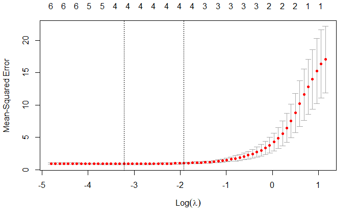

```r
plot(mod.lasso)
```

```r
# Next fit the model on entire data using best lambda
best.model = glmnet(xmat, Y, alpha = 1)
predict(best.model, s = best.lambda, type = "coefficients")
```

```
11 x 1 sparse Matrix of class "dgCMatrix"
                                  s1
(Intercept)             3.0398151056
poly(x, 10, raw = T)1   2.2303371338
poly(x, 10, raw = T)2  -3.1033192679
poly(x, 10, raw = T)3   .
poly(x, 10, raw = T)4   .
poly(x, 10, raw = T)5   0.0498410763
poly(x, 10, raw = T)6   .
poly(x, 10, raw = T)7   0.0008068431
poly(x, 10, raw = T)8   .
poly(x, 10, raw = T)9   .
poly(x, 10, raw = T)10  .
```

Lasso also picks X5 over X3. It also picks X7 with negligible coefficient.

6. Now generate a response vector Y according to the model Y = β0 + β7X7 + ϵ, and perform best subset selection and the lasso. Discuss the results obtained.

Create new Y with different β7=7.

```r
beta7 = 7
Y = beta0 + beta7 * X^7 + eps
# Predict using regsubsets
data.full = data.frame(y = Y, x = X)
mod.full = regsubsets(y ~ poly(x, 10, raw = T), data = data.full, nvmax = 10)
mod.summary = summary(mod.full)

# Find the model size for best cp, BIC and adjr2
which.min(mod.summary$cp)
```

```
[1] 2
```

```r
which.min(mod.summary$bic)
```

```
[1] 1
```

```r
which.max(mod.summary$adjr2)
```

```
[1] 4
```

```r
coefficients(mod.full, id = 1)
```

```
          (Intercept) poly(x, 10, raw = T)7
              2.95894               7.00077
```

```r
coefficients(mod.full, id = 2)
```

```
          (Intercept) poly(x, 10, raw = T)2
            3.0704904            -0.1417084
poly(x, 10, raw = T)7
            7.0015552
```

```r
coefficients(mod.full, id = 4)
```

```
          (Intercept) poly(x, 10, raw = T)1
            3.0762524             0.2914016
poly(x, 10, raw = T)2 poly(x, 10, raw = T)3
           -0.1617671            -0.2526527
poly(x, 10, raw = T)7
            7.0091338
```

```r
xmat = model.matrix(y ~ poly(x, 10, raw = T), data = data.full)[, -1]
mod.lasso = cv.glmnet(xmat, Y, alpha = 1)
best.lambda = mod.lasso$lambda.min
best.lambda
```

```
[1] 12.36884
```

```r
best.model = glmnet(xmat, Y, alpha = 1)
predict(best.model, s = best.lambda, type = "coefficients")
```

```
11 x 1 sparse Matrix of class "dgCMatrix"
                             s1
(Intercept)            3.820215
poly(x, 10, raw = T)1  .
poly(x, 10, raw = T)2  .
poly(x, 10, raw = T)3  .
poly(x, 10, raw = T)4  .
poly(x, 10, raw = T)5  .
poly(x, 10, raw = T)6  .
poly(x, 10, raw = T)7  6.796694
poly(x, 10, raw = T)8  .
poly(x, 10, raw = T)9  .
poly(x, 10, raw = T)10 .
```

Lasso also picks the best 1-variable model but intercet is quite off (3.8 vs 3).

*9. In this exercise, we will predict the number of applications received using the other variables in the College data set.*

1. Split the data set into a training set and a test set.

```r
library(ISLR)
set.seed(11)
sum(is.na(College))
```

```
[1] 0
```

```r
train.size = dim(College)[1] / 2
train = sample(1:dim(College)[1], train.size)
test = -train
College.train = College[train, ]
College.test = College[test, ]
```

2. Fit a linear model using least squares on the training set, and report the test error obtained.

```r
lm.fit = lm(Apps~., data=College.train)
lm.pred = predict(lm.fit, College.test)
mean((College.test[, "Apps"] - lm.pred)^2)
```

```
[1] 1026096
```

Test RSS is 1026096.

3. Fit a ridge regression model on the training set, with λ chosen by cross-validation. Report the test error obtained.

```r
library(glmnet)
```

```r
train.mat = model.matrix(Apps~., data=College.train)
test.mat = model.matrix(Apps~., data=College.test)
grid = 10 ^ seq(4, -2, length=100)
mod.ridge = cv.glmnet(train.mat, College.train[, "Apps"], alpha=0, lambda=grid, thresh=1e-12)
lambda.best = mod.ridge$lambda.min
lambda.best
```

```
[1] 0.01
```

```r
ridge.pred = predict(mod.ridge, newx=test.mat, s=lambda.best)
mean((College.test[, "Apps"] - ridge.pred)^2)
```

```
[1] 1026069
```

Test RSS is almost equal to OLS, 1026069.

4. Fit a lasso model on the training set, with λ chosen by crossvalidation. Report the test error obtained, along with the number of non-zero coefficient estimates.

```r
mod.lasso = cv.glmnet(train.mat, College.train[, "Apps"], alpha=1, lambda=grid, thresh=1e-12)
lambda.best = mod.lasso$lambda.min
lambda.best
```

```
[1] 0.01
```

```r
lasso.pred = predict(mod.lasso, newx=test.mat, s=lambda.best)
mean((College.test[, "Apps"] - lasso.pred)^2)
```

```
[1] 1026036
```

Test RSS is almost equal to OLS, 1026036.

```r
mod.lasso = glmnet(model.matrix(Apps~., data=College), College[, "Apps"], alpha=1)
predict(mod.lasso, s=lambda.best, type="coefficients")
```

```
19 x 1 sparse Matrix of class "dgCMatrix"
                       s1
(Intercept) -471.39372052
(Intercept)    .
PrivateYes  -491.04485137
Accept         1.57033288
Enroll        -0.75961467
Top10perc     48.14698892
Top25perc    -12.84690695
F.Undergrad    0.04149116
P.Undergrad    0.04438973
Outstate      -0.08328388
Room.Board     0.14943472
Books          0.01532293
Personal       0.02909954
PhD           -8.39597537
Terminal      -3.26800340
S.F.Ratio     14.59298267
perc.alumni   -0.04404771
Expend         0.07712632
Grad.Rate      8.28950241
```